# The Capacitated Vehicle Routing Problem

[figure not shown]

*It appears that we are on to something!*

*The mTSP model gave us some promising results, so we decided to go ahead with the multiple delivery campaigns that will run in parallel. But it turns out that the sleighs have limited capacity.*

*Can you help?*

We knew that the mTSP model is not the ideal solution. Not only are the tours uneven, but we have no way to take into account the capacity of the vehicle, or the possibility that the nodes have different levels of demand.

If we would like to incorporate these aspects in our analysis, then we would need to follow a VRP-based approach.

```python
import numpy as np
import matplotlib
import matplotlib.pyplot as plt
import seaborn as sns; sns.set()
from sklearn.datasets import make_blobs

%matplotlib inline

plot_size   = 30
plot_width  = 38
plot_height = 20

params = {'legend.fontsize': 'large',
          'figure.figsize': (plot_width,plot_height),
          'axes.labelsize': plot_size,
          'axes.titlesize': plot_size,
          'xtick.labelsize': plot_size*0.75,
          'ytick.labelsize': plot_size*0.75,
          'axes.titlepad': 25}
plt.rcParams.update(params)
```

```python
num_customer = 10
num_facility = 1
num_vehicles = 3
```

```python
center_box = (100, 200)

cust_coord, _  = make_blobs(n_samples=num_customer,
                            centers=2,
                            cluster_std=20,
                            center_box=center_box,
                            random_state = 2)

facil_coord, _ = make_blobs(n_samples=num_facility,
                            centers=1,
                            cluster_std=1,
                            center_box=center_box,
                            random_state = 50)
```

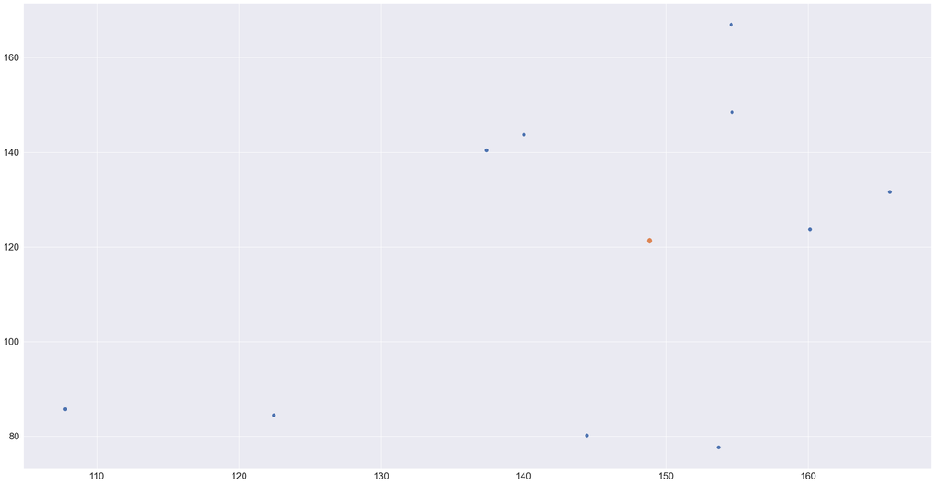

```python
plt.scatter(cust_coord[:, 0],
            cust_coord[:, 1],
            s=plot_size*2,
            cmap='viridis');

plt.scatter(facil_coord[:, 0],
            facil_coord[:, 1],
            s=plot_size*5,
            cmap='viridis');
```

We combine all nodes into a single list.

```python
all_coord = list(facil_coord) + list(cust_coord)
all_coord
```

```
[array([148.83923613, 121.34372996]),
 array([165.7474142 , 131.60904527]),
 array([154.62857111, 148.43678344]),
 array([137.40408992, 140.40355585]),
 array([154.58363786, 167.03226365]),
 array([140.0088288 , 143.71274428]),
 array([107.73077851,  85.75767587]),
 array([153.65711856,  77.68686145]),
 array([160.09765683, 123.75665829]),
 array([144.43027807,  80.23411428]),
 array([122.44044584,  84.41247088])]
```

```python
from scipy.spatial import distance

dist_matrix = distance.cdist(all_coord, all_coord, 'euclidean')
```

```python
payload = 4
cost = 100
budget = 100000
```

```python
S = [('S'+str(i+1)) for i in range(num_facility)]
D = [('D'+str(i+1)) for i in range(num_customer)]
N = S + D
```

```python
d = {customer:{facility:dist_matrix[i][j] for j,facility in enumerate(N)} for i,customer in enumerate(N)}
```

```python
from pulp import *

prob = LpProblem('prob', LpMinimize)
```

```python
x = LpVariable.dicts('x', (N,N), lowBound = 0, upBound = 1, cat = LpInteger)
f = LpVariable.dicts('f', (N,N), lowBound = 0, cat = LpInteger)
```

```python
prob += lpSum([x[i][j]*d[i][j] for j in N for i in N]) + lpSum([cost * x[i][j] for i in S for j in D])
```

```python
for i in D:
    prob += lpSum([x[j][i] for j in N]) - lpSum([x[i][j] for j in N]) == 0

for i in D:
    prob += lpSum([f[j][i] for j in N]) - lpSum([f[i][j] for j in N]) == 1

for i in N:
    for j in N:
        prob += f[i][j] <= payload * x[i][j]

for i in N:
    for j in S:
        prob += f[i][j] == 0

for i in N:
    prob += x[i][i] == 0

for i in S:
    prob += lpSum([x[i][j] for j in D]) >= 1

for i in D:
    prob += lpSum([x[i][j] for j in N]) == 1

for i in D:
    for j in D:
        prob += x[i][j] + x[j][i] <= 1

prob += lpSum([cost * x[i][j] for i in S for j in D]) <= budget
```

```python
status = prob.solve()

print(f'STATUS\n{LpStatus[status]}\n')
```

```
STATUS
Optimal
```

```python
route_num = 1
for i,facility in enumerate(S):
    for j,customer in enumerate(D):
        if x[facility][customer].varValue >= 1:
            dest = customer
            print(f'Route #{route_num}:')
            print(f'{facility}, {customer}: {x[facility][customer].varValue}, {f[facility][customer].varValue}')
            route_num += 1
            while dest != facility:
                orig = dest
                for k in N:
                    if x[orig][k].varValue >= 1:
                        dest = k
                        print(f'{orig}, {dest}: {x[orig][dest].varValue}, {f[orig][dest].varValue}')
```

```
Route #1:
S1, D2: 1.0, 4.0
D2, D4: 1.0, 3.0
D4, D5: 1.0, 2.0
D5, D3: 1.0, 1.0
D3, S1: 1.0, 0.0
Route #2:
S1, D6: 1.0, 4.0
D6, D10: 1.0, 3.0
D10, D9: 1.0, 2.0
D9, D7: 1.0, 1.0
D7, S1: 1.0, 0.0
Route #3:
S1, D8: 1.0, 2.0
D8, D1: 1.0, 1.0
D1, S1: 1.0, 0.0
```

```python
vect_orig = []
vect_dest = []
arrw_width = []
arrw_color = []

u = v = np.zeros((len(vect_orig),len(vect_orig)))

for i,orig in enumerate(N):
    for j,dest in enumerate(N):
        if x[orig][dest].varValue >= 1:
            vect_orig.append(all_coord[j])
            vect_dest.append(all_coord[i])
            arrw_width.append(f[orig][dest].varValue)

vect_orig = np.array(vect_orig)
vect_dest = np.array(vect_dest)
```

In the above code we are iterating through our sets of facilities and customers.

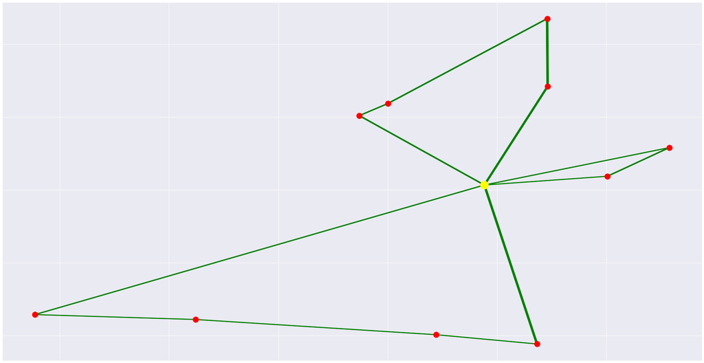

```python
plt.scatter(cust_coord[:, 0], cust_coord[:, 1], s=plot_size*10, color='red', zorder = 10000);
plt.scatter(facil_coord[:, 0], facil_coord[:, 1], s=plot_size*20, color='yellow', zorder = 10000);

for i in range(len(vect_orig)):
    plt.arrow(vect_orig[i][0],vect_orig[i][1],vect_dest[i][0]-vect_orig[i][0],vect_dest[i][1]-vect_orig[i][1],
              width=0.2,#arrw_width[i] / 2000,
              head_width=0,color='green',zorder = 1)

frame1 = plt.gca(); frame1.axes.xaxis.set_ticklabels([]); frame1.axes.yaxis.set_ticklabels([]);
```

## Summary

```
from pulp import *
from scipy.spatial import distance

# Calculate distance matrix
dist_matrix = distance.cdist(cust_coord, facil_coord, 'euclidean')

# Initialise problem
prob = LpProblem('prob', LpMinimize)

# Define sets of customers and facilities
S = [('S'+str(i+1)) for i in range(num_facility)]
D = [('D'+str(i+1)) for i in range(num_customer)]
H = [('H'+str(i+1)) for i in range(num_vehicles)]
N = S + D

# Prepare distance matrix parameters
d = {customer:{facility:dist_matrix[i][j] for j,facility in enumerate(N)} for i,customer in enumerate(N)}
p = {vehicle:payload[i] for i,vehicle in enumerate(H)}
c = {vehicle:cost_h[i] for i,vehicle in enumerate(H)}

# Define decision variables
x = LpVariable.dicts('x', (N,N), lowBound = 0, upBound = 1, cat = LpInteger)
f = LpVariable.dicts('f', (N,N), lowBound = 0, cat = LpInteger)

# Objective function
prob += lpSum([lpSum([x[i][j]*d[i][j]]) for j in N for i in N]) + lpSum([cost * x[i][j] for i in S for j in D])

# Constraint 1: Vehicle Equilibrium
for i in D:
    prob += lpSum([x[j][i] for j in N]) - lpSum([x[i][j] for j in N]) == 0

# Constraint 2: Flow Equilibrium (assuming demand of one unit of cargo at each demand point)
for i in D:
    prob += lpSum([f[j][i] for j in N]) - lpSum([f[i][j] for j in N]) == 1

# Constraint 3: Cargo flow must not exceed vehicle payload
for i in N:
    for j in N:
        prob += f[i][j] <= payload * x[i][j]

# Constraint 4: Return to the supply depot with no cargo
for i in N:
    for j in S:
        prob += f[i][j] == 0

# Constraint 5: Ensure no vehicle waits at any node
for i in N:
    prob += x[i][i] == 0

# Constraint 6: Ensure that at least one vehicle leaves the depot
for i in S:
    prob += lpSum([x[i][j] for j in D]) >= 1

# Constraint 7: All nodes must be visited
for i in D:
    prob += lpSum([x[i][j] for j in N]) == 1

# Constraint 8: Sub-tour elimination
for i in D:
    for j in D:
        prob += x[i][j] + x[j][i] <= 1

# Constraint 9: Budget constraint
prob += lpSum([cost * x[i][j] for i in S for j in D]) <= budget

# Solve the model
status = prob.solve()
```